# Tugas 2

Davina Rachmadyanti

2023-09-05

# **Persiapan Libraries**

```r
library("rio")
library(dplyr)
library(TTR)
library(forecast)
library(lmtest) #digunakan untuk uji formal pendeteksian autokorelasi
library(orcutt) #untuk membuat model regresi Cochrane-Orcutt
library(HoRM) #untuk membuat model regresi Hildreth-Lu
```

# Persiapan Data

```r
input <- import("https://raw.githubusercontent.com/davinarachmadyanti/mpdw/main/Pertemuan%202/Wine%20Data.csv")
input
```

```
##      Year CommodityCode   CropName CountyCode        County HarvestedAcres
## 1    1980        216299 GRAPESWINE          1       Alameda           1660
## 2    1980        216299 GRAPESWINE          5        Amador            912
## 3    1980        216299 GRAPESWINE          9     Calaveras             50
## 4    1980        216299 GRAPESWINE         19        Fresno          35170
## 5    1980        216299 GRAPESWINE         29          Kern          36339
## 6    1980        216299 GRAPESWINE         31         Kings           1122
## 7    1980        216299 GRAPESWINE         33          Lake           2990
## 8    1980        216299 GRAPESWINE         39        Madera          26251
## 9    1980        216299 GRAPESWINE         47        Merced          13333
## 10   1980        216299 GRAPESWINE         55          Napa          22261
## 11   1980        216299 GRAPESWINE         65     Riverside           1701
## 12   1980        216299 GRAPESWINE         67    Sacramento           3350
## 13   1980        216299 GRAPESWINE         69     SanBenito           4500
## 14   1980        216299 GRAPESWINE         71 SanBernardino          10060
```

[output cut: 2617 more lines]

```r
data = input[input$County=="Kings",]
data = cbind(data$Year,data$Production,data$HarvestedAcres)
data = as.data.frame(data)
colnames(data) = c("Year","Production","HarvestedAcres")
data
```

```
##    Year Production HarvestedAcres
## 1  1980       8864           1122
## 2  1981       6215           1029
## 3  1982      11331           1074
## 4  1983       9417           1290
## 5  1984       9774           1117
## 6  1985      13292           1117
## 7  1986      14568           1214
## 8  1987      12140           1214
## 9  1988       7200            800
## 10 1989       7670            954
## 11 1990       9710           1111
## 12 1991      10121           1111
## 13 1992      19891           2407
## 14 1993      20996           1712
```

[output cut: 27 more lines]

# **Eksplorasi Data**

Akan diperlihatkan plot time-series dari area panen (dalam acre) dan total produksi (dalam ton) Wine County Kings Periode 1980-2020

```r
#Membentuk objek time series
data_production.ts<-ts(data$Production)
data_production.ts
```

```
## Time Series:
## Start = 1
## End = 41
## Frequency = 1
##  [1]  8864  6215 11331  9417  9774 13292 14568 12140  7200  7670  9710 10121
## [13] 19891 20996 25049 12344 23268 28707 29322 34941 27311 30088 28294 29555
## [25] 31720 47009 39800 28719 37306 50698 48900 54200 53000 58300 57400 40600
## [37] 50800 56300 55300 63100 59100
```

```r
data_harvested.ts<-ts(data$HarvestedAcres)
data_harvested.ts
```

```
## Time Series:
## Start = 1
## End = 41
## Frequency = 1
##  [1] 1122 1029 1074 1290 1117 1117 1214 1214  800  954 1111 1111 2407 1712 1884
## [16] 2057 2087 2115 2168 2263 3020 3085 3319 3295 3023 3717 3624 3817 3831 4122
## [31] 4130 3590 4110 4280 4800 3330 3730 3600 3670 3670 3590
```

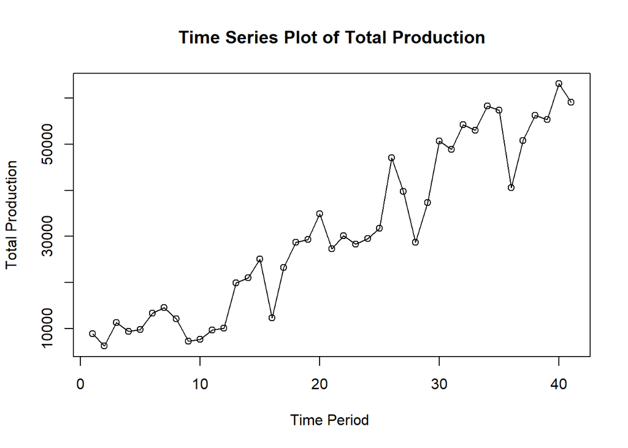

```r
#Membuat plot time series
ts.plot(data_production.ts, xlab="Time Period ", ylab="Total Production", main= "Time Series Plot of Total Production")
points(data_production.ts)
```

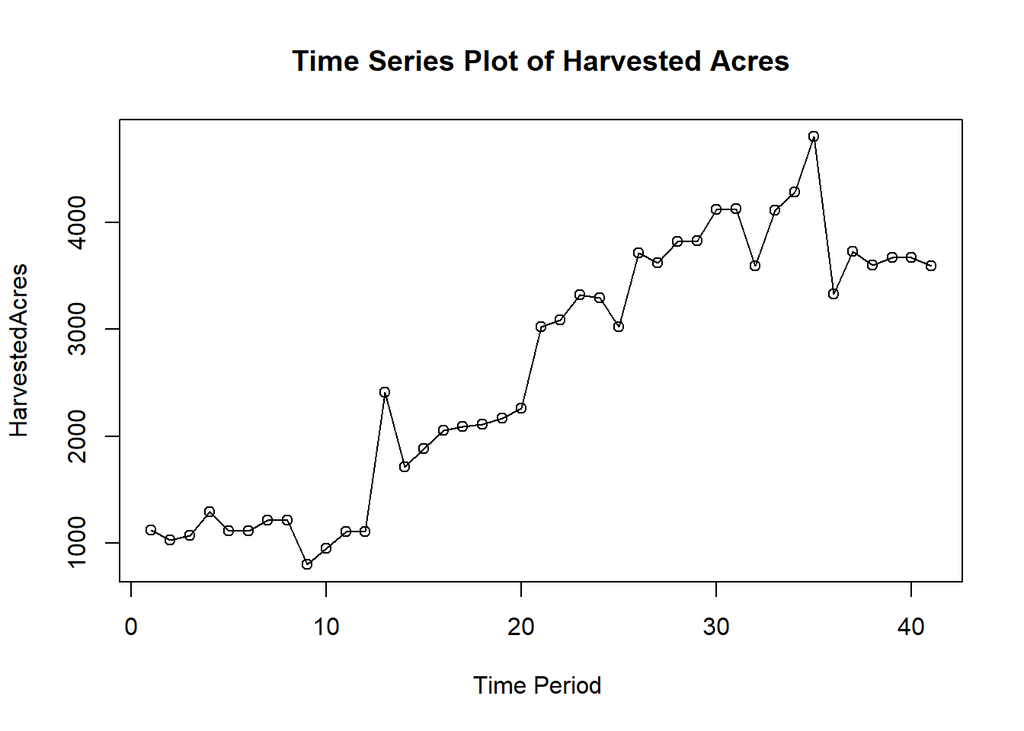

```r
ts.plot(data_harvested.ts, xlab="Time Period ", ylab="HarvestedAcres", main= "Time Series Plot of Harvested Acres")
points(data_harvested.ts)
```

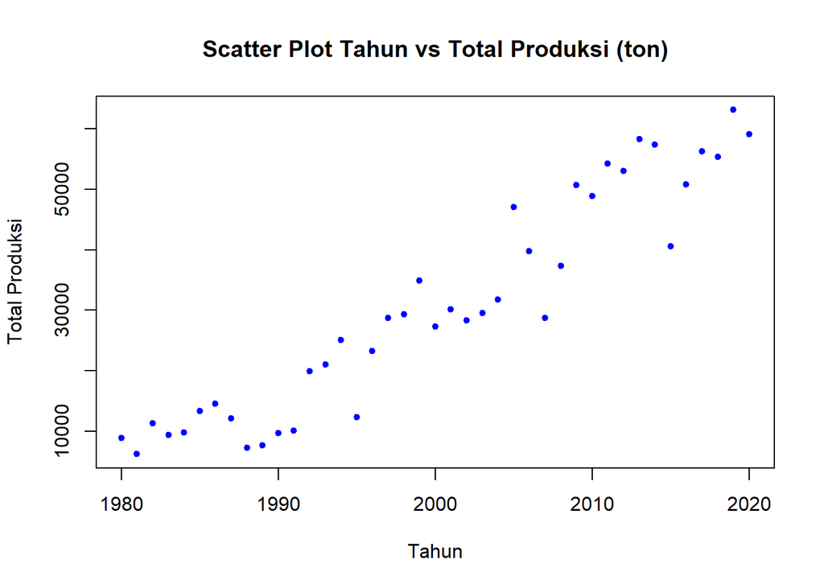

```r
#Eksplorasi Data
#Pembuatan Scatter Plot
plot(data$Year,data$Production, pch = 20, col = "blue",
     main = "Scatter Plot Tahun vs Total Produksi (ton)",
     xlab = "Tahun",
     ylab = "Total Produksi")
```

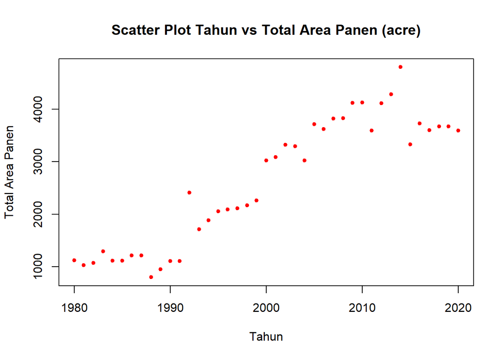

```r
plot(data$Year,data$HarvestedAcres, pch = 20, col = "red",
     main = "Scatter Plot Tahun vs Total Area Panen (acre)",
     xlab = "Tahun",
     ylab = "Total Area Panen")
```

```r
#Menampilkan Nilai Korelasi
cor(data$Year,data$Production)
```

```
## [1] 0.9489174
```

```r
cor(data$Year,data$HarvestedAcres)
```

```
## [1] 0.9195421
```

Terlihat bahwa data cenderung menunjukkan pola trend

# **Regresi**

```r
#Pembuatan Model Regresi
#model regresi
model<- lm(Production~Year+HarvestedAcres, data = data)
summary(model)
```

```
##
## Call:
## lm(formula = Production ~ Year + HarvestedAcres, data = data)
##
## Residuals:
##    Min     1Q Median     3Q    Max
## -14240  -4511   1499   3545   7783
##
## Coefficients:
##                  Estimate Std. Error t value Pr(>|t|)
## (Intercept)    -2.142e+06  3.694e+05  -5.800 1.07e-06 ***
## Year            1.082e+03  1.869e+02   5.786 1.12e-06 ***
## HarvestedAcres  3.825e+00  1.855e+00   2.062   0.0461 *
## ---
## Signif. codes:  0 '***' 0.001 '**' 0.01 '*' 0.05 '.' 0.1 ' ' 1
##
## Residual standard error: 5566 on 38 degrees of freedom
## Multiple R-squared:  0.9105, Adjusted R-squared:  0.9057
## F-statistic: 193.2 on 2 and 38 DF,  p-value: < 2.2e-16
```

Model yang dihasilkan adalah

$$y_i=-(2.14e+06)+1082x_1+3.825x_2$$

Berdasarkan ringkasan model dapat diketahui bahwa hasil uji F memiliki *p-value* < $\alpha$ (5%).

Artinya, minimal terdapat satu variabel yang berpengaruh nyata terhadap model. Begitu juga dengan hasil uji-t parsial kedua parameter regresi, yaitu intersep dan koefisien regresi 1 dan 2 yang menunjukkan hal yang sama, yaitu memiliki p-value < $\alpha$ (5%) sehingga baik peubah Year (tahun) maupun HarvestedAcres (area panen) memiliki pengaruh yang nyata terhadap peubah Production (produksi) dalam taraf 5%.

Selanjutnya dapat dilihat juga nilai $R^2=0.9105$. Artinya, sebesar 91.05% keragaman Production (produksi) dapat dijelaskan oleh peubah Year (tahun) dan HarvestedAcres (luas area panen).

Selanjutnya kita perlu melakukan uji terhadap sisaannya untuk melihat kondisi normalitas dan indikasi autokorelasi

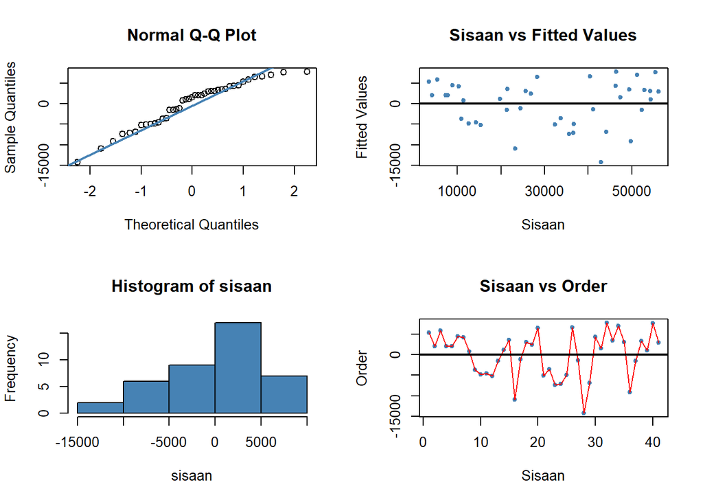

```r
#sisaan dan fitted value
sisaan<- residuals(model)
fitValue<- predict(model)

#Diagnostik dengan eksploratif
par(mfrow = c(2,2))
qqnorm(sisaan)
qqline(sisaan, col = "steelblue", lwd = 2)
plot(fitValue, sisaan, col = "steelblue", pch = 20, xlab = "Sisaan", ylab = "Fitted Values", main = "Sisaan vs Fitted Values")
abline(a = 0, b = 0, lwd = 2)
hist(sisaan, col = "steelblue")
plot(seq(1,41,1), sisaan, col = "steelblue", pch = 20, xlab = "Sisaan", ylab = "Order", main = "Sisaan vs Order")
lines(seq(1,41,1), sisaan, col = "red")
abline(a = 0, b = 0, lwd = 2)
```

Dua plot di samping kiri digunakan untuk melihat apakah sisaan menyebar normal. Normal Q-Q Plot di atas menunjukkan bahwa sisaan cenderung mengikuti sebaran normal, begitu juga dengan histogram dari sisaan.

Selanjutnya, dua plot di samping kanan digunakan untuk melihat autokorelasi. Plot Sisaan vs Fitted Value dan Plot Sisaan vs Order menunjukkan adanya pola pada sisaan, hal ini mengindikasikan adanya autokorelasi.

Untuk lebih lanjut akan digunakan uji formal melihat normalitas sisaan dan plot ACF dan PACF untuk melihat apakah ada autokorelasi atau tidak.

## Uji Normalitas

Uji ini dilakukan untuk melihat apakah sisaan menyebar normal atau tidak. Kali ini uji yang digunakan adalah *Shapiro Test* dan *Kolmogorov-Smirnov Test*

```r
#Melihat Sisaan Menyebar Normal/Tidak
#H0: sisaan mengikuti sebaran normal
#H1: sisaan tidak mengikuti sebaran normal
shapiro.test(sisaan)
```

```
##
##  Shapiro-Wilk normality test
##
## data:  sisaan
## W = 0.94716, p-value = 0.05566
```

```r
ks.test(sisaan, "pnorm", mean=mean(sisaan), sd=sd(sisaan))
```

```
##
##  Exact one-sample Kolmogorov-Smirnov test
##
## data:  sisaan
## D = 0.1418, p-value = 0.3486
## alternative hypothesis: two-sided
```

Berdasarkan uji formal Saphiro-Wilk dan Kolmogorov-Smirnov didapatkan nilai *p-value* > $\alpha$ (5%), sehingga keputusannya adalah terima H0. Artinya, cukup bukti untuk menyatakan sisaan berdistribusi normal.

## Uji Autokorelasi

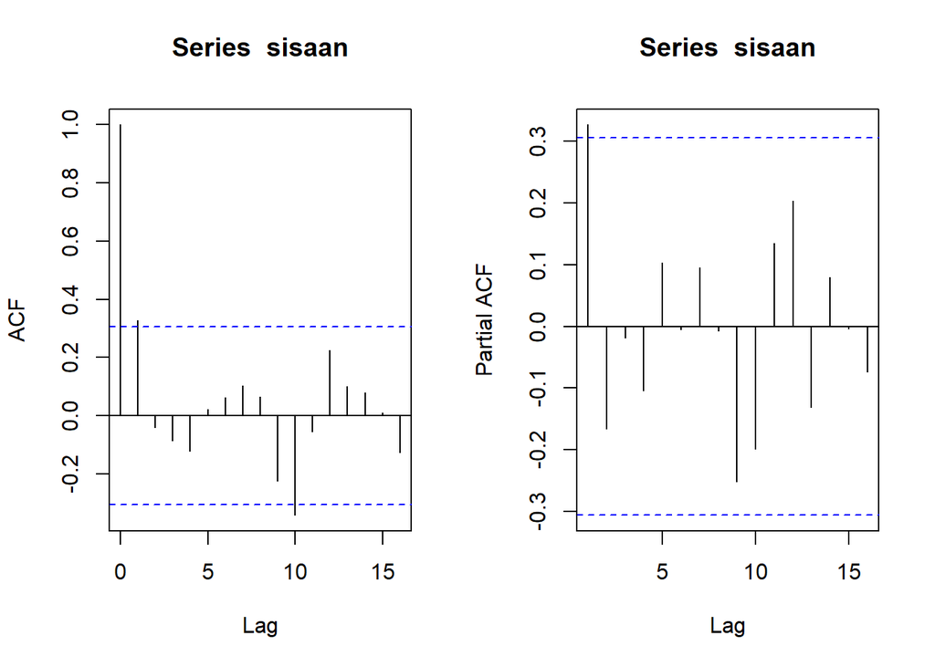

```r
#ACF dan PACF identifikasi autokorelasi
par(mfrow = c(1,2))
acf(sisaan)
pacf(sisaan)
```

Berdasarkan plot ACF dan PACF, terlihat terdapat garis vertikal yang melebihi rentang batas (garis biru), hal ini mengindikasikan adanya autokorelasi. Namun, untuk lebih memastikan akan dilakukan uji formal dengan uji *Durbin Watson.*

```r
#Deteksi autokorelasi dengan uji-Durbin Watson
#H0: tidak ada autokorelasi
#H1: ada autokorelasi
dwtest(model)
```

```
##
##  Durbin-Watson test
##
## data:  model
## DW = 1.3137, p-value = 0.004819
## alternative hypothesis: true autocorrelation is greater than 0
```

Berdasarkan hasil DW Test, didapatkan nilai $DW = 1.3137$ dan p-value = $0.004819$. Berdasarkan tabel Durbin-Watson diperoleh nilai $DL = 1.3992$ dan $DU = 1.6031$. Nilai DW yang lebih kecil dari DL mengindikasikan terjadinya autokorelasi.

Hal ini didukung juga oleh nilai *p-value* < 0.05 dapat disimpulkan bahwa tolak H0, artinya cukup bukti mengatakan adanya autokorelasi. Oleh karena itu, diperlukan penangan autokorelasi. Penanganan yang akan digunakan menggunakan dua metode, yaitu *Cochrane-Orcutt* dan *Hildret-Lu*.

### Penanganan Autokorelasi

#### Metode Cochrance-Orcutt

Penanganan metode *Cochrane-Orcutt* dapat dilakukan dengan bantuan packages Orcutt pada aplikasi R maupun secara manual. Berikut ini ditampilkan cara menggunakan bantuan library packages Orcutt.

```r
#Penanganan Autokorelasi Cochrane-Orcutt
modelCO<-cochrane.orcutt(model)
modelCO
```

```
## Cochrane-orcutt estimation for first order autocorrelation
##
## Call:
## lm(formula = Production ~ Year + HarvestedAcres, data = data)
##
##  number of interaction: 7
##  rho 0.339488
##
## Durbin-Watson statistic
## (original):    1.31367 , p-value: 4.819e-03
## (transformed): 1.90195 , p-value: 2.958e-01
##
##  coefficients:
##    (Intercept)           Year HarvestedAcres
##  -2.115470e+06   1.067307e+03   4.380576e+00
```

Hasil keluaran model setelah dilakukan penanganan adalah sebagai berikut.

$$y_i=-(2.12e+06)+1067.31x_1+4.38x_2$$

Untuk nilai $ρ ̂$ optimum yang digunakan adalah $0.339488$. Nilai tersebut dapat diketahui dengan syntax berikut

```r
#Rho optimum
rho<- modelCO$rho
rho
```

```
## [1] 0.339488
```

Selanjutnya akan dilakukan transformasi secara manual dengan syntax berikut ini.

```r
#Transformasi Manual
Production.trans<- data$Production[-1]-data$Production[-41]*rho
Year.trans<- data$Year[-1]-data$Year[-41]*rho
HarvestedAcres.trans<- data$HarvestedAcres[-1]-data$HarvestedAcres[-41]*rho
modelCOmanual<- lm(Production.trans~Year.trans+HarvestedAcres.trans)
summary(modelCOmanual)
```

```
##
## Call:
## lm(formula = Production.trans ~ Year.trans + HarvestedAcres.trans)
##
## Residuals:
##      Min       1Q   Median       3Q      Max
## -14065.7  -2616.1    385.6   3516.3   7921.6
##
## Coefficients:
##                        Estimate Std. Error t value Pr(>|t|)
## (Intercept)          -1.397e+06  2.896e+05  -4.824 2.42e-05 ***
## Year.trans            1.067e+03  2.216e+02   4.817 2.48e-05 ***
## HarvestedAcres.trans  4.381e+00  2.076e+00   2.110   0.0417 *
## ---
## Signif. codes:  0 '***' 0.001 '**' 0.01 '*' 0.05 '.' 0.1 ' ' 1
##
## Residual standard error: 5238 on 37 degrees of freedom
## Multiple R-squared:  0.8361, Adjusted R-squared:  0.8273
## F-statistic: 94.38 on 2 and 37 DF,  p-value: 2.944e-15
```

```r
#Mencari Penduga Koefisien Regresi setelah Transformasi ke Persamaan Awal
modelCOmanual$coefficients
```

```
##          (Intercept)           Year.trans HarvestedAcres.trans
##        -1.397293e+06         1.067307e+03         4.380576e+00
```

```r
b0bintang <- modelCOmanual$coefficients[1]
b0 <- b0bintang/(1-rho)
b1 <- modelCOmanual$coefficients[2]
b2 <- modelCOmanual$coefficients[3]
b0
```

```
## (Intercept)
##    -2115470
```

```r
b1
```

```
## Year.trans
##   1067.307
```

```r
b2
```

```
## HarvestedAcres.trans
##             4.380576
```

Hasil perhitungan koefisien regresi tersebut akan menghasilkan hasil yang sama dengan model yang dihasilkan menggunakan packages.

#### Metode Hildreth-Lu

Penanganan kedua adalah menggunakan metode Hildreth-Lu. Metode ini akan mencari nilai SSE terkecil dan dapat dicari secara manual maupun menggunakan packages. Jika menggunakan packages, gunakan library packages HORM.

```r
#Penanganan Autokorelasi Hildreth lu
# Hildreth-Lu
hildreth.lu.func<- function(r, model){
  x <- model.matrix(model)[,-1]
  y <- model.response(model.frame(model))
  n <- length(y)
  t <- 2:n
  y <- y[t]-r*y[t-1]
  x <- x[t]-r*x[t-1]

  return(lm(y~x))
}

#Pencariab rho yang meminimumkan SSE
r <- c(seq(0.1,0.9, by= 0.1))
tab <- data.frame("rho" = r, "SSE" = sapply(r, function(i){deviance(hildreth.lu.func(i, model))}))
round(tab, 4)
```

```
##   rho        SSE
## 1 0.1 1191016616
## 2 0.2 1150435846
## 3 0.3 1136026607
## 4 0.4 1147788900
## 5 0.5 1185722724
## 6 0.6 1249828080
## 7 0.7 1340104967
## 8 0.8 1456553386
## 9 0.9 1599173336
```

Pertama-tama akan dicari di mana kira-kira $ρ$ yang menghasilkan SSE minimum. Pada hasil di atas terlihat $ρ$ minimum ketika 0.3. Namun, hasil tersebut masih kurang teliti sehingga akan dicari kembali $ρ$ yang lebih optimum dengan ketelitian yang lebih. Jika sebelumnya jarak antar $ρ$ yang dicari adalah 0.1, kali ini jarak antar $ρ$ adalah 0.001 dan dilakukan pada selang 0.2 sampai dengan 0.5.

```r
#Rho optimal di sekitar 0.4
rOpt <- seq(0.2,0.5, by= 0.001)
tabOpt <- data.frame("rho" = rOpt, "SSE" = sapply(rOpt, function(i){deviance(hildreth.lu.func(i, model))}))
head(tabOpt[order(tabOpt$SSE),])
```

```
##       rho        SSE
## 106 0.305 1135993148
## 107 0.306 1135994307
## 105 0.304 1135994605
## 108 0.307 1135998084
## 104 0.303 1135998680
## 109 0.308 1136004478
```

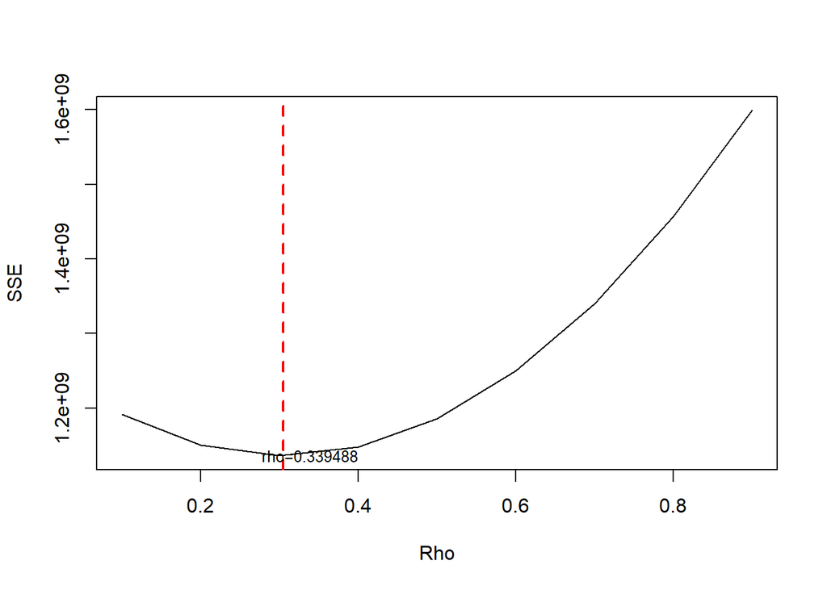

```r
#Grafik SSE optimum
par(mfrow = c(1,1))
plot(tab$SSE ~ tab$rho , type = "l", xlab = "Rho", ylab = "SSE")
abline(v = tabOpt[tabOpt$SSE==min(tabOpt$SSE),"rho"], lty = 2, col="red",lwd=2)
text(x=0.339488, y=1136026607, labels = "rho=0.339488", cex = 0.8)
```

```r
#Model terbaik
modelHL <- hildreth.lu.func(0.339488, model)
summary(modelHL)
```

```
##
## Call:
## lm(formula = y ~ x)
##
## Residuals:
##      Min       1Q   Median       3Q      Max
## -14136.0  -3038.2    982.1   3179.6  10732.4
##
## Coefficients:
##               Estimate Std. Error t value Pr(>|t|)
## (Intercept) -1928134.1   149963.7  -12.86 2.05e-15 ***
## x               1474.8      113.5   13.00 1.46e-15 ***
## ---
## Signif. codes:  0 '***' 0.001 '**' 0.01 '*' 0.05 '.' 0.1 ' ' 1
##
## Residual standard error: 5471 on 38 degrees of freedom
## Multiple R-squared:  0.8164, Adjusted R-squared:  0.8116
## F-statistic:   169 on 1 and 38 DF,  p-value: 1.462e-15
```

```r
#Transformasi Balik
cat("y = ", coef(modelHL)[1]/(1-0.339488), "+", coef(modelHL)[2],"x", sep = "")
```

```
## y = -2919151+1474.819x
```

` Setelah dilakukan tranformasi balik, didapatkan model dengan metode Hildreth-Lu sebagai berikut.

```r
#Deteksi autokorelasi
#H0: tidak ada autokorelasi
#H1: ada autokorelasi
dwtest(modelHL)
```

```
##
##  Durbin-Watson test
##
## data:  modelHL
## DW = 1.9768, p-value = 0.4036
## alternative hypothesis: true autocorrelation is greater than 0
```

Hasil uji Durbin-Watson juga menunjukkan bawah nilai DW sebesar $1.9768$ berada pada selang daerah tidak ada autokorelasi, yaitu pada rentang DU < DW < 4-DU atau $1.6031 < DW < 2.3969$.

Hal tersebut juga didukung oleh *p-value* sebesar $0.4036$, di mana *p-value* > $\alpha$=5%. Artinya tak tolak $H_0$ atau belum cukup bukti menyatakan bahwa ada autokorelasi dalam data nilai Produksi dengan metode Hildreth-Lu pada taraf nyata 5%.

Terakhir, akan dibandingkan nilai SSE dari ketiga metode (metode awal, metode Cochrane-Orcutt, dan Hildreth-Lu).

```r
#Perbandingan
sseModelawal <- anova(model)$`Sum Sq`[1]
sseModelCO <- anova(modelCOmanual)$`Sum Sq`[1]
sseModelHL <- anova(modelHL)$`Sum Sq`[1]
mseModelawal <- sseModelawal/length(data$Production)
mseModelCO <- sseModelCO/length(data$Production)
mseModelHL <- sseModelHL/length(data$Production)
akurasi <- matrix(c(sseModelawal,sseModelCO,sseModelHL,
                    mseModelawal,mseModelCO,mseModelHL),nrow=2,ncol=3,byrow = T)
colnames(akurasi) <- c("Model Awal", "Model Cochrane-Orcutt", "Model Hildreth-Lu")
row.names(akurasi) <- c("SSE","MSE")
akurasi
```

```
##      Model Awal Model Cochrane-Orcutt Model Hildreth-Lu
## SSE 11837263935            5057849550        5057848894
## MSE   288713755             123362184         123362168
```

# Simpulan

Autokorelasi yang terdapat pada data Production terjadi akibat adanya korelasi di antara unsur penyusunnya. Peubah Production yang erat hubungannya dengan perkebunan sangat rawan menjadi penyebab adanya autokorelasi. Adanya autokorelasi menyebabkan model regresi kurang baik karena akan meingkatkan galatnya. Autokorelasi dapat dideteksi secara eksploratif melalui plot sisaan, ACF, dan PACF, serta dengan uji formal Durbin-Watson. Namun, autokorelasi tersebut dapat ditangani dengan metode Cochrane-Orcutt dan Hildreth-Lu. Kedua metode menghasilkan nilai SSE yang sama, artinya keduanya baik untuk digunakan.